# R4DS_2E_dateTime

Martin

2026-01-19

## Dates and times - Creating date/times

1. What happens if you parse a string that contains invalid dates?

```r
ymd(c("2010-10-10", "bananas"))
```

```
## [1] "2010-10-10" NA
```

```r
# Warning:  1 failed to parse.[1] "2010-10-10" NA
```

2. What does the tzone argument to today() do? Why is it important?

```r
today(tzone = "GMT") # UK time zone
```

```
## [1] "2026-01-19"
```

```r
today(tzone = "EST") # US time zone
```

```
## [1] "2026-01-19"
```

```r
# The tzone argument is self-explanatory. Its important as somebody in China using the `today` function at the exact same time as myself (UK) might end up having a different day presented than myself
```

3. For each of the following date-times, show how you’d parse it using a readr column specification and a lubridate function.

```r
d1 <- "January 1, 2010"
d2 <- "2015-Mar-07"
d3 <- "06-Jun-2017"
d4 <- c("August 19 (2015)", "July 1 (2015)")
d5 <- "12/30/14" # Dec 30, 2014
t1 <- "1705"
t2 <- "11:15:10.12 PM"

mdy(d1)
```

```
## [1] "2010-01-01"
```

```r
parse_date(d1, "%B %d, %Y")
```

```
## [1] "2010-01-01"
```

```r
ymd(d2)
```

```
## [1] "2015-03-07"
```

```r
parse_date(d2, "%Y-%b-%D")
```

```
## [1] "2015-07-01"
```

```r
dmy(d3)
```

```
## [1] "2017-06-06"
```

```r
parse_date(d3, "%D-%b-%Y")
```

```
## [1] "2017-06-01"
```

```r
mdy(d4)
```

```
## [1] "2015-08-19" "2015-07-01"
```

```r
parse_date(d4, "%B %d (%Y)")
```

```
## [1] "2015-08-19" "2015-07-01"
```

```r
mdy(d5)
```

```
## [1] "2014-12-30"
```

```r
parse_date(d5, "%m/%d/%y")
```

```
## [1] "2014-12-30"
```

```r
# Much easier to not using lubridate for the following time
parse_time(t1, "%H%M")
```

```
## 17:05:00
```

```r
hms(t2)
```

```
## [1] "11H 15M 10.12S"
```

```r
parse_time(t2, "%I:%M:%OS %p")
```

```
## 23:15:10.12
```

## Dates and times - Date-time components

```r
# Use the following for the following questions:
make_datetime_100 <- function(year, month, day, time) {
  make_datetime(year, month, day, time %/% 100, time %% 100)
}

flights_dt <- flights |>
  filter(!is.na(dep_time), !is.na(arr_time)) |>
  mutate(
    dep_time = make_datetime_100(year, month, day, dep_time),
    arr_time = make_datetime_100(year, month, day, arr_time),
    sched_dep_time = make_datetime_100(year, month, day, sched_dep_time),
    sched_arr_time = make_datetime_100(year, month, day, sched_arr_time)
  ) |>
  select(origin, dest, ends_with("delay"), ends_with("time"))

flights_dt
```

```
## # A tibble: 328,063 × 9
##    origin dest  dep_delay arr_delay dep_time            sched_dep_time
##    <chr>  <chr>     <dbl>     <dbl> <dttm>              <dttm>
##  1 EWR    IAH           2        11 2013-01-01 05:17:00 2013-01-01 05:15:00
##  2 LGA    IAH           4        20 2013-01-01 05:33:00 2013-01-01 05:29:00
##  3 JFK    MIA           2        33 2013-01-01 05:42:00 2013-01-01 05:40:00
##  4 JFK    BQN          -1       -18 2013-01-01 05:44:00 2013-01-01 05:45:00
##  5 LGA    ATL          -6       -25 2013-01-01 05:54:00 2013-01-01 06:00:00
##  6 EWR    ORD          -4        12 2013-01-01 05:54:00 2013-01-01 05:58:00
##  7 EWR    FLL          -5        19 2013-01-01 05:55:00 2013-01-01 06:00:00
##  8 LGA    IAD          -3       -14 2013-01-01 05:57:00 2013-01-01 06:00:00
##  9 JFK    MCO          -3        -8 2013-01-01 05:57:00 2013-01-01 06:00:00
## 10 LGA    ORD          -2         8 2013-01-01 05:58:00 2013-01-01 06:00:00
## # ℹ 328,053 more rows
## # ℹ 3 more variables: arr_time <dttm>, sched_arr_time <dttm>, air_time <dbl>
```

1. How does the distribution of flight times within a day change over the course of the year?

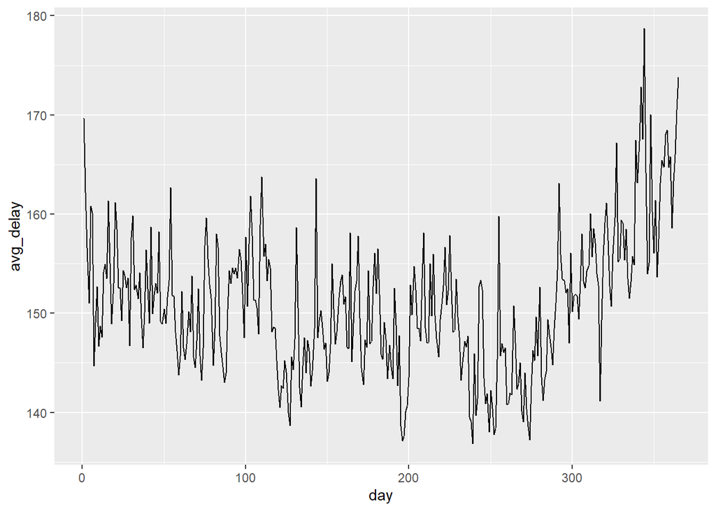

```r
flights_dt |>
  mutate(day = yday(dep_time)) |>
  group_by(day) |>
  mutate(
    avg_delay = mean(air_time, na.rm = TRUE),
    n = n()
    ) |>
  ggplot(aes(x = day, y = avg_delay)) +
  geom_line()
```

```r
# Seems to be a downwards trend through the start of the year to pre-holiday months, then a sharp increase especially in the Christmas period
```

2. Compare dep_time, sched_dep_time and dep_delay. Are they consistent? Explain your findings.

Answer: They would be consistent if sched_dep_time - dep_time = dep_delay

```r
flights_dt |>
  count(consistent = (sched_dep_time - dep_time) == (dep_delay))
```

```
## # A tibble: 2 × 2
##   consistent      n
##   <lgl>       <int>
## 1 FALSE      311565
## 2 TRUE        16498
```

```r
# We can see this is not the case for the majority of the timings, likely due to some natural human error where there will always be a few seconds off.
```

3. Compare air_time with the duration between the departure and arrival. Explain your findings. (Hint: consider the location of the airport.)

Answer: Similar to the above we should expect the arrival time minus departure time to equal total air time

```r
flights_dt |>
  count(consistent = (arr_time - dep_time) == (air_time))
```

```
## # A tibble: 3 × 2
##   consistent      n
##   <lgl>       <int>
## 1 FALSE      327150
## 2 TRUE          196
## 3 NA            717
```

```r
# Again vast majority of the flights are FALSE, only a couple hundred are TRUE and some are NA likely due to cancelled flights.

flights_dt |>
  mutate(consistent = (arr_time - dep_time) == (air_time)) |>
  relocate(origin, dest, dep_time, arr_time, air_time, consistent) |>
  filter(consistent == TRUE) |>
  count(origin, dest)
```

```
## # A tibble: 40 × 3
##    origin dest      n
##    <chr>  <chr> <int>
##  1 EWR    AUS       1
##  2 EWR    BNA       2
##  3 EWR    DFW       6
##  4 EWR    DSM       1
##  5 EWR    HOU       1
##  6 EWR    IAH       5
##  7 EWR    MCI       1
##  8 EWR    MDW       2
##  9 EWR    MSP       3
## 10 EWR    OMA       1
## # ℹ 30 more rows
```

```r
# I can't seem to find much pattern. Check transform.Rmd for a better explanation
```

4. How does the average delay time change over the course of a day? Should you use dep_time or sched_dep_time? Why?

Answer: We should use scheduled departure times as this is what passengers will be using to know approximately when they should be arriving for their flight. As a passenger it would be useful to see what scheduled departure times have the highest delays in time so that you could plan better (Perhaps getting a flight at a less delayed time).

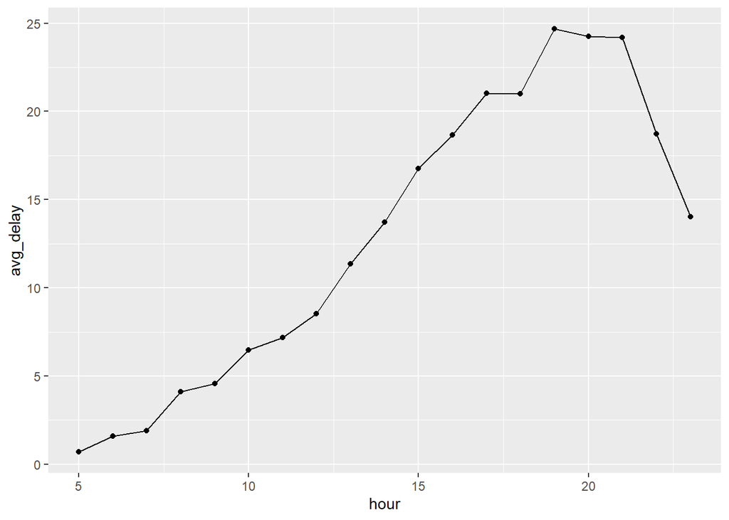

```r
flights_dt |>
  mutate(hour = hour(sched_dep_time)) |>
  group_by(hour) |>
  summarize(
    avg_delay = mean(dep_delay, na.rm = TRUE),
    n = n()
  ) |>
  ggplot(aes(x = hour, y = avg_delay)) +
  geom_line() +
  geom_point()
```

```r
# It steadily increases from 5 in the morning to about 7 in the evening, stagnates till 9 then sharply decreases as most of the days congestion is clearing at these late times
```

5. On what day of the week should you leave if you want to minimise the chance of a delay?

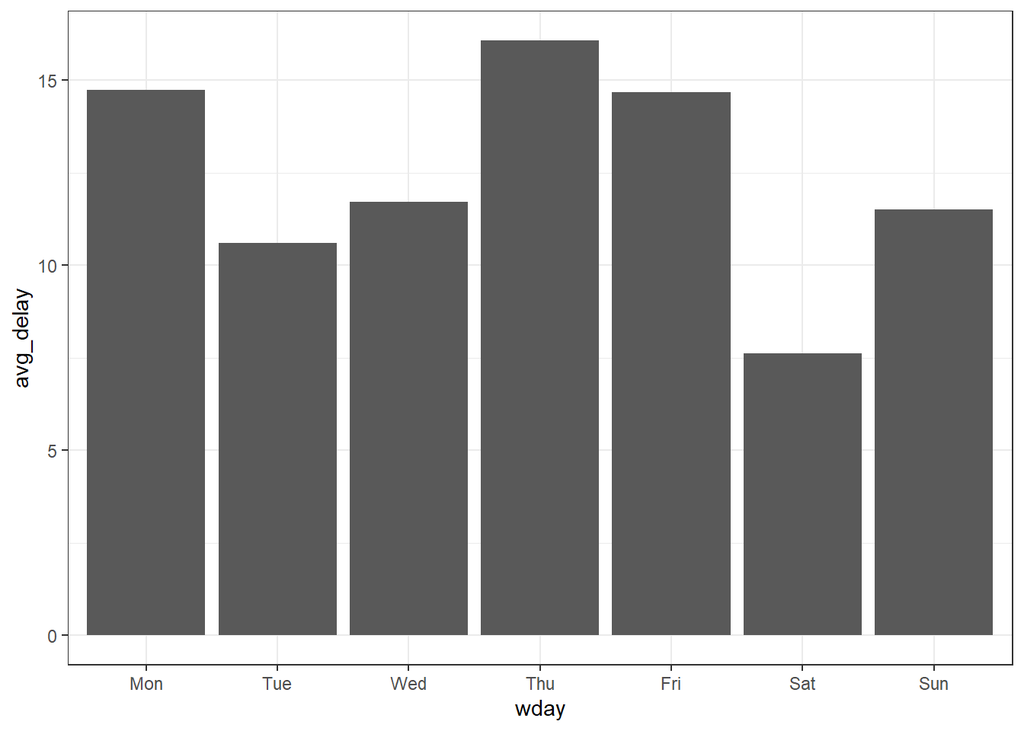

```r
flights_dt |>
  mutate(wday = wday(sched_dep_time, label = TRUE)) |>
  mutate(wday = factor(wday, levels = c("Mon", "Tue", "Wed", "Thu", "Fri", "Sat", "Sun"))) |>
  group_by(wday) |>
  summarize(
    avg_delay = mean(dep_delay, na.rm = TRUE),
    n = n()
  ) |>
  ggplot(aes(wday, avg_delay)) +
  geom_histogram(stat = "identity") +
  theme_bw()
```

```r
# Best day of the week to leave is on a Saturday
```

6. What makes the distribution of diamonds$carat and flights$sched_dep_time similar?

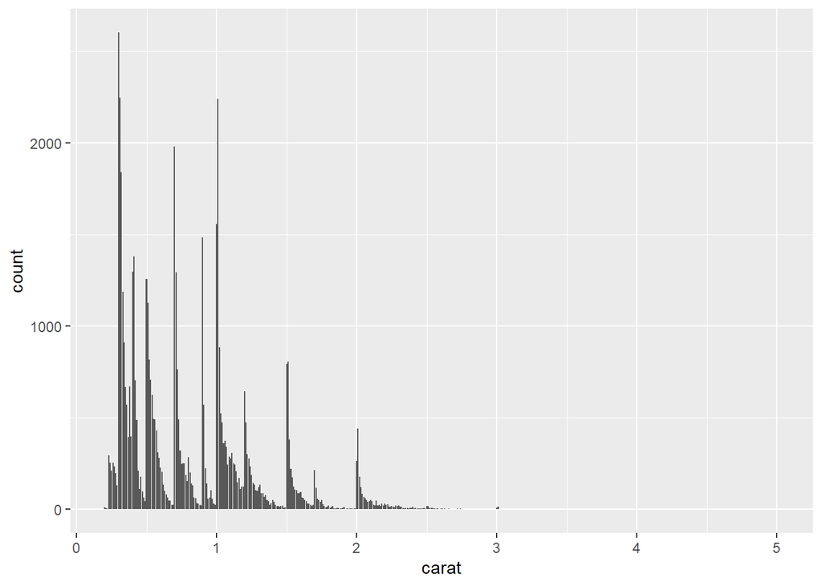

```r
ggplot(diamonds, aes(x = carat)) +
  geom_bar()
```